# Health and Economic Impact of Weather Events in the US

# Most Harmful Events Data

prepare FATALITIES, INJURIES,PROPDMG,CROPDMG Data

To analyze economic damage:

Property damage is represented with two fields, `PROPDMG` in dollars and the exponent `PROPDMGEXP`.

Crop damage is represented using two fields, `CROPDMG` and `CROPDMGEXP`.

```r
# prepare FATALITIES, INJURIES,PROPDMG,CROPDMG
storm$FATALITIES <- as.numeric( storm$FATALITIES )
storm$INJURIES <- as.numeric( storm$INJURIES )
```

#### Prepare Property Damage Data

```r
# prepare  PROPDMG
storm$PROPDMG <- as.numeric( storm$PROPDMG )

#clean prop  data
storm$PROPDMGEXP<-  gsub('^ $', '',storm$PROPDMGEXP)
storm$PROPDMGEXP <- gsub('[-?+]', 0, storm$PROPDMGEXP)
storm$PROPDMGEXP <- gsub('^$', 0, storm$PROPDMGEXP)

# sub letter with numbers
# h ->hundred, k - 1000, m -> million, b is billion...convert to million
storm$PROPDMGEXP <- gsub('[Hh]', .0001, storm$PROPDMGEXP)
storm$PROPDMGEXP <- gsub('[Kk]', .001, storm$PROPDMGEXP)
storm$PROPDMGEXP <- gsub('[Mm]', 1, storm$PROPDMGEXP)
storm$PROPDMGEXP <- gsub('[Bb]', 1000, storm$PROPDMGEXP)

#calc prop  damage in millions
storm$PROPDMG <- as.numeric(storm$PROPDMG*as.numeric(storm$PROPDMGEXP))
```

#### Prepare Crop Damage Data

```r
# prepare  CROPDMG
storm$CROPDMG <- as.numeric( storm$CROPDMG )

#clean prop and crop data
storm$CROPDMGEXP<-  gsub('^ $', '',storm$CROPDMGEXP)
storm$CROPDMGEXP <- gsub('[-?+]', 0, storm$CROPDMGEXP)
storm$CROPDMGEXP <- gsub('^$', 0, storm$CROPDMGEXP)

# sub letter with numbers
# h ->hundred, k - 1000, m -> million, b is billion...convert to million
storm$CROPDMGEXP <- gsub('[Hh]', .0001, storm$CROPDMGEXP)
storm$CROPDMGEXP <- gsub('[Kk]', .001, storm$CROPDMGEXP)
storm$CROPDMGEXP <- gsub('[Mm]', 1, storm$CROPDMGEXP)
storm$CROPDMGEXP <- gsub('[Bb]', 1000, storm$CROPDMGEXP)

#calc crop damage in millions
storm$CROPDMG <- as.numeric(storm$CROPDMG*as.numeric(storm$CROPDMGEXP))
```

#### Top 10 events that caused largest number of deaths are

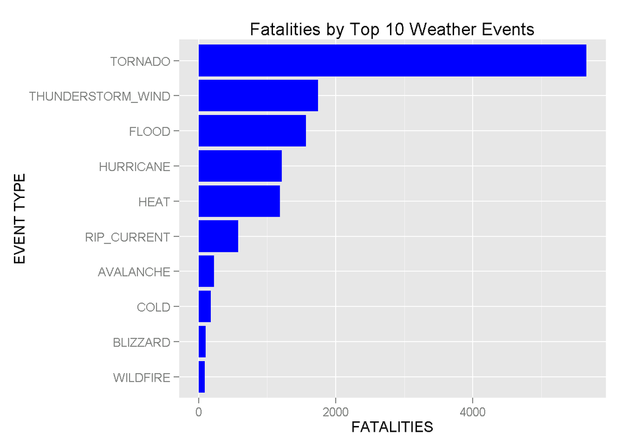

```r
library(ggplot2)
# calc fatal data
fatal  <- aggregate(  storm$FATALITIES , list( event =storm$stormClass), sum )
fatal <-fatal[order(fatal$x, decreasing = TRUE), ]
ggplot(fatal[1:10,], aes(x = reorder(event, x), y = x)) +
    geom_bar(stat = "identity", fill = "blue", las = 3) +
    coord_flip() +
    xlab("EVENT TYPE") + ylab("FATALITIES") +
    ggtitle("Fatalities by Top 10 Weather Events")
```

#### Top 10 events that caused most number of injuries are

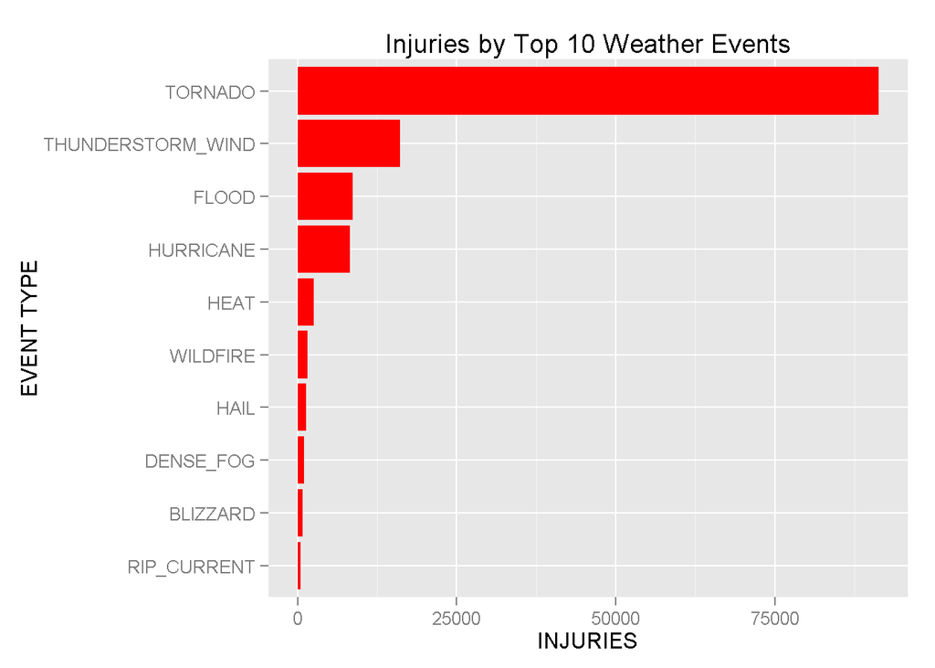

```r
# calc injury data
injury  <- aggregate(  storm$INJURIES , list( event =storm$stormClass), sum )
colnames(injury) <- c("event", "total")
injury <-injury[order(injury$total, decreasing = TRUE), ]
ggplot(injury[1:10,], aes(x = reorder(event, total), y = total)) +
    geom_bar(stat = "identity", fill = "red" ) +
    coord_flip() +
    xlab("EVENT TYPE") + ylab("INJURIES") +
    ggtitle("Injuries by Top 10 Weather Events")
```

#### Top 10 events that caused most property damage (in dollars) are

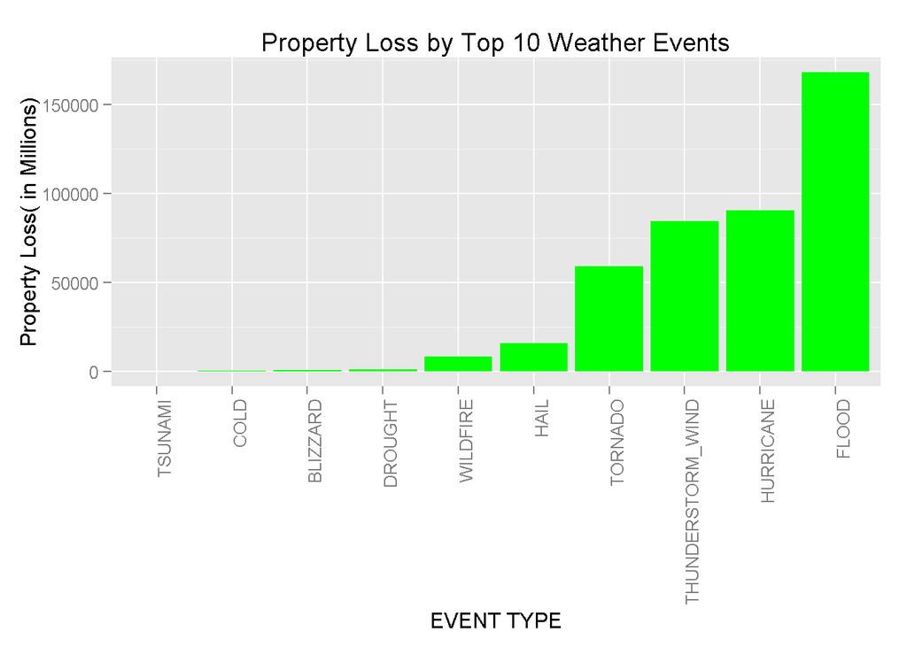

```r
prop <- aggregate( storm$PROPDMG , list( event =storm$stormClass), sum )
names(prop) <- c("event", "loss")
prop <-prop[order(prop$loss, decreasing = TRUE), ]

ggplot(prop[1:10,], aes(x = reorder(event, loss), y = loss)) +
    geom_bar(stat = "identity", fill = "green" ) +
    theme(axis.text.x = element_text(angle = 90, hjust = 1)) +
    xlab("EVENT TYPE") + ylab("Property Loss( in Millions)") +
    ggtitle("Property Loss by Top 10 Weather Events")
```

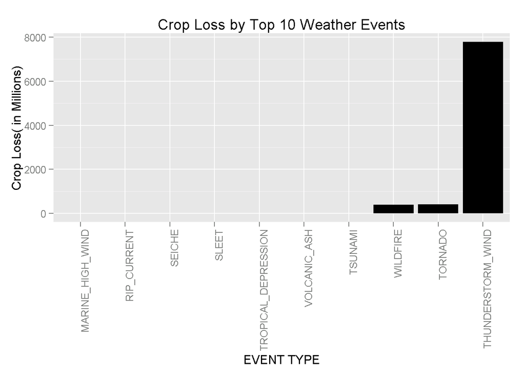

```r
crop <- aggregate( storm$CROPDMG , list( event =storm$stormClass), sum )
names(crop) <- c("event", "loss")
crop <-crop[order(crop, decreasing = TRUE), ]

ggplot(crop[1:10,], aes(x = reorder(event, loss), y = loss)) +
    geom_bar(stat = "identity", fill = "black" ) +
    theme(axis.text.x = element_text(angle = 90, hjust = 1)) +
    xlab("EVENT TYPE") + ylab("Crop Loss( in Millions)") +
    ggtitle("Crop Loss by Top 10 Weather Events")
```

# Results

#### Population Death & Injury

Based on NOAA data, Tornadoes cause most number of deaths and injuries among all event types. There are more than 5,000 deaths and more than 75,000 injuries in the last 60 years in US, due to tornadoes. The other event types that are most dangerous with respect to population health are wind and floods.

#### Economic consequences to Property

The most severe weather event in terms of property damage is the Flood. In the last half century, the flood has caused more than 150 billion dollars damage. Other severe property-damage-causing event types are hurricane and wind.